# Box Office Blues

## Exploratory Analysis

Before creating the models, we go through a process of data exploration with tmdb_movies_small to understand the value range of various features, their relationships with each other and with Revenue, our target variable.

Here is a snippet of the data with the columns under consideration:

```r
ft <- flextable(head(tmdb_movies_small, n=10))
ft <- autofit(ft)
ft
```

| original_title | revenue | budget | popularity | vote_average | vote_count | runtime | release_month | release_year | first_genre | is_big_banner |
| --- | --- | --- | --- | --- | --- | --- | --- | --- | --- | --- |
| Avatar | 2787965087 | 237000000 | 150.44 | 7.2 | 11800 | 162 | 12 | 2009 | 28 | TRUE |
| Pirates of the Caribbean: At World's End | 961000000 | 300000000 | 139.08 | 6.9 | 4500 | 169 | 05 | 2007 | 12 | TRUE |
| Spectre | 880674609 | 245000000 | 107.38 | 6.3 | 4466 | 148 | 10 | 2015 | 28 | TRUE |
| The Dark Knight Rises | 1084939099 | 250000000 | 112.31 | 7.6 | 9106 | 165 | 07 | 2012 | 28 | TRUE |
| John Carter | 284139100 | 260000000 | 43.93 | 6.1 | 2124 | 132 | 03 | 2012 | 28 | TRUE |
| Spider-Man 3 | 890871626 | 258000000 | 115.70 | 5.9 | 3576 | 139 | 05 | 2007 | 14 | TRUE |
| Tangled | 591794936 | 260000000 | 48.68 | 7.4 | 3330 | 100 | 11 | 2010 | 16 | TRUE |
| Avengers: Age of Ultron | 1405403694 | 280000000 | 134.28 | 7.3 | 6767 | 141 | 04 | 2015 | 28 | TRUE |
| Harry Potter and the Half-Blood Prince | 933959197 | 250000000 | 98.89 | 7.4 | 5293 | 153 | 07 | 2009 | 12 | TRUE |
| Batman v Superman: Dawn of Justice | 873260194 | 250000000 | 155.79 | 5.7 | 7004 | 151 | 03 | 2016 | 28 | TRUE |

Following the tenets outlined earlier, we make the following decisions:

```r
#Find rows with 0 values and set to NA
tmdb_movies_small[tmdb_movies_small$revenue == 0, "revenue" ] = NA
tmdb_movies_small[tmdb_movies_small$budget == 0, "budget" ] = NA
tmdb_movies_small[tmdb_movies_small$popularity == 0, "popularity" ] = NA
#tmdb_movies_small[tmdb_movies_small$vote_count == 0, "vote_average" ] = NA

tmdb_movies_small$release_year = as.integer(tmdb_movies_small$release_year)
tmdb_movies_small$release_month = as.factor(tmdb_movies_small$release_month)
tmdb_movies_small$first_genre = as.factor(tmdb_movies_small$first_genre)
tmdb_movies_small$is_big_banner = as.factor(tmdb_movies_small$is_big_banner)

#remove invalid rows
tmdb_movies_small =  na.omit(tmdb_movies_small)

#dropping original_title as we build the models. Retaining tmdb_movies_small so we can use original_title during results analysis
tmdb_movies_small_no_title = subset(tmdb_movies_small, select = -c(original_title))
```

We drop the movie title column from tmdb_movies_small. If needed, we will look at the title later during results analysis.

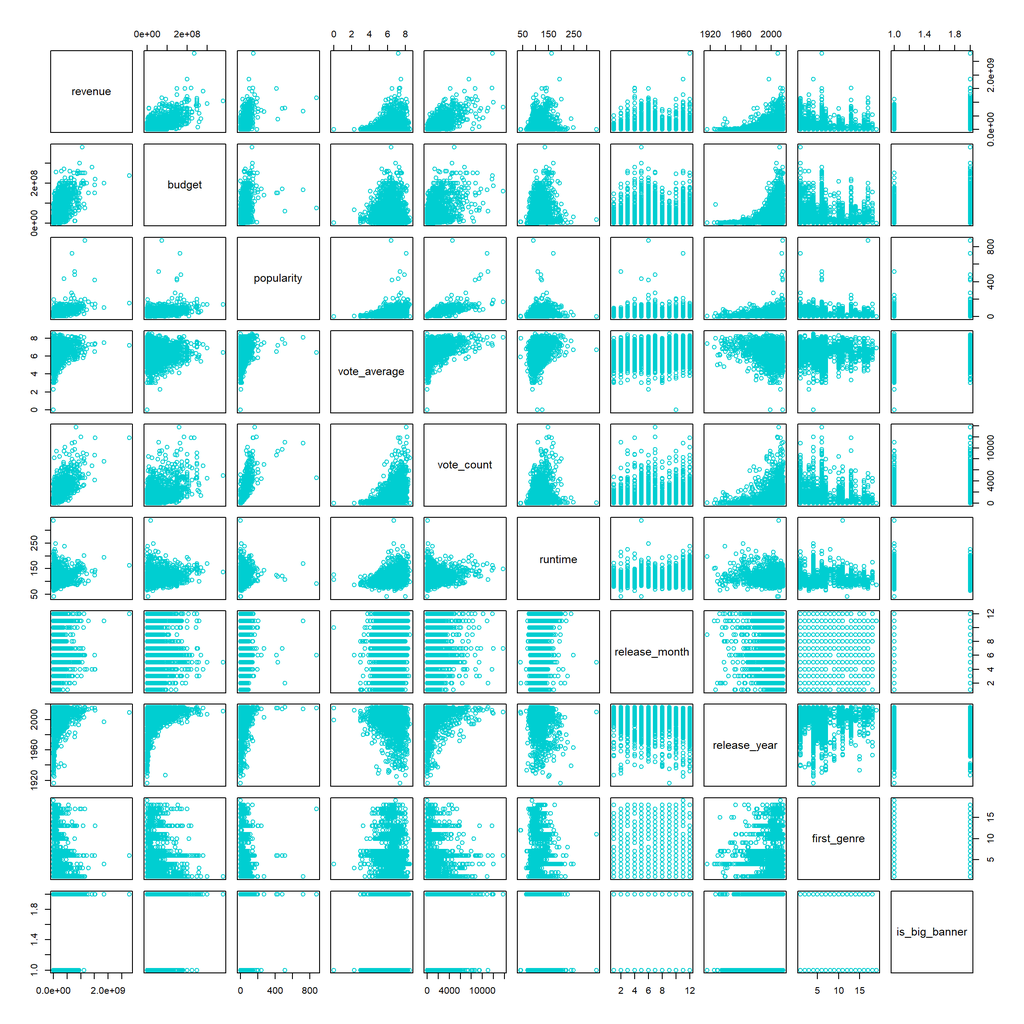

```r
pairs(tmdb_movies_small_no_title, col = cbPalette[2])
```

Interestingly from pairs plots the release month seems to have impact on the revenue - with movies released in summer months (April/May/June) and Nov/Dec months having a higher revenue than other months on average. Since month is factor variable we leave it unmodified. The pairs plot of numeric variables show positive relationship which we investigate with correlation table below.

```r
cor(tmdb_movies_small_no_title[,1:6])
```

```
##              revenue   budget popularity vote_average vote_count runtime
## revenue       1.0000  0.70535     0.6022      0.18762     0.7562  0.2332
## budget        0.7054  1.00000     0.4319     -0.03163     0.5401  0.2296
## popularity    0.6022  0.43187     1.0000      0.28675     0.7490  0.1823
## vote_average  0.1876 -0.03163     0.2868      1.00000     0.3775  0.3790
## vote_count    0.7562  0.54008     0.7490      0.37750     1.0000  0.2580
## runtime       0.2332  0.22964     0.1823      0.37899     0.2580  1.0000
```

From the correlation table of the numeric predictors we can see the vote count and budget of a movie seems to have highest and positive correlation with revenue. This is followed by popularity. The vote average and run time seems to have low correlation with revenue.

## Test-Train Split

```r
tmdb_movies_small_no_title_mod = subset(tmdb_movies_small_no_title, budget>50000)
#tmdb_movies_small_no_title_mod = removeInfluencers(tmdb_movies_small_no_title_mod1)
```

We removed the records which has the budget <50K as those are the outliers.These rows typically have a very low and unrealistic target variable (revenue) like $1 ,$10 etc.

```r
set.seed(420)
train_idx  = sample(nrow(tmdb_movies_small_no_title_mod), size = trunc(0.80 * nrow(tmdb_movies_small_no_title_mod)))

tmdb_movies_train = tmdb_movies_small_no_title_mod[train_idx, ]
tmdb_movies_test = tmdb_movies_small_no_title_mod[-train_idx, ]
```

We withold a validation set so that we can assess model performance. We split our tmdb_movies_small dataset randomly into 2 parts - train (80% ) and test(20%).

- **Train Dataset**: The train dataset is used to train the models and also create a leave-oneout cross-validated RMSE (loocv_rmse). By creating RMSE scores for different sets created by leaving one observation out, we obtain a measure that can be used to assess how the model will generalize. Lower the loocv_rmse, better the model performance against unseen data.
- **Test Dataset**: We run every model on the test dataset and obtain the average percent error as a measure of model generalization.

### Issue: Unseen Factor Levels

Because of the test-train split, we encounter a new problem with respect to categorical variables during model building. If the test dataset contains unseen values for a factor variable, the model would output errors while trying to predict revenue for the test dataset. Our approach is to drop those rows from test set before we begin modeling.

```r
# We need to make sure our training set has all the values for the factor variables, else when we call predict on the test data set, we get errors. Our approach is to drop those rows from test set before we begin modeling.

drop_new_factor_levels = function(i) {
   train_i = tmdb_movies_train[, i]
   test_i = tmdb_movies_test[, i]

   diff = (unique(test_i) %in% unique(train_i))
   if (is.factor(test_i) & any(!diff)) {
      test_i_levels = unique(test_i)
      apply(test_i ==
              matrix(rep(test_i_levels[diff], each = nrow(tmdb_movies_test)),
                     nrow = nrow(tmdb_movies_test)),
            1,
            any)
   } else {
      rep(TRUE, nrow(tmdb_movies_test))
   }
}

keep = apply(sapply(1:ncol(tmdb_movies_test),
                    drop_new_factor_levels),
             1,
             all)
tmdb_movies_test = tmdb_movies_test[keep, ]
```

[output not shown]

## Baseline: Simple Additive Model

Our model creation process starts with a simple additive model with two predictors that we can use as a baseline.

```r
boxoffice_model_1 = lm(revenue ~  budget + popularity , tmdb_movies_small)
results_simple = get_model_results(boxoffice_model_1)
revenue_mod_results = rbind(revenue_mod_results,
                          (tibble_row(model_name = "Baseline",
                                      model = results_simple$model,
                                      model_rse = results_simple$model_rse,
                                      adj_r2 = results_simple$adj_r2,
                                      model_test_rmse = results_simple$model_test_rmse,
                                      num_params = results_simple$num_params,
                                      sw_value = results_simple$sw_value,
                                      sw_decision = results_simple$sw_decision,
                                      bp_value = results_simple$bp_value,
                                      bp_decision = results_simple$bp_decision
                                      )))
```

Looking at the model summary, the two predictors, popularity and budget, appear to be significiant and the model has an Adjusted $R^2$ of 0.6061. Our objective is to improve this simplistic model and find the best performing model as the preferred model for predicting revenue. Various attributes of the baseline model are stored for later analysis.

## Full Additive Model

Our second step is to evaluate a full additive model. Apart from the usual results, we also check the Variance Inflation Factor for the predictors and check for high correlation between the predictors.

```r
fit_revenue_add = lm(revenue ~ .,
                     data = tmdb_movies_train)

results_add = get_model_results(fit_revenue_add)
revenue_mod_results_discard = rbind(revenue_mod_results_discard,
                          (tibble_row(model_name = "Full Additive",
                                      model = results_add$model,
                                       model_rse = results_add$model_rse,
                                      adj_r2 = results_add$adj_r2,
                                      model_test_rmse = results_add$model_test_rmse,
                                      num_params = results_add$num_params,
                                      sw_value = results_add$sw_value,
                                      sw_decision = results_add$sw_decision,
                                      bp_value = results_add$bp_value,
                                      bp_decision = results_add$bp_decision
                                      )))
```

### Variance Inflation Factors

```r
vif_revenue_add = car::vif(fit_revenue_add)
 knitr::kable(vif_revenue_add,
              caption = "<center><strong>Variance Inflation Factors</strong></center>") %>%
          kable_styling(bootstrap_options = c("striped", "hover", "condensed", "responsive"))
```

**Variance Inflation Factors**

|  | GVIF | Df | GVIF^(1/(2*Df)) |
| --- | --- | --- | --- |
| budget | 2.184 | 1 | 1.478 |
| popularity | 2.206 | 1 | 1.485 |
| vote_average | 1.661 | 1 | 1.289 |
| vote_count | 2.999 | 1 | 1.732 |
| runtime | 1.664 | 1 | 1.290 |
| release_month | 1.378 | 11 | 1.015 |
| release_year | 1.319 | 1 | 1.149 |
| first_genre | 2.231 | 18 | 1.022 |
| is_big_banner | 1.160 | 1 | 1.077 |

We find that all the VIF values are less than 5 which is desirable. We draw the conclusion that none of the predictors are highly collinear and we can include all of them in the model if there is support from other considerations like test statistics and p_values.

## Additive Model Improvements

With the full additive model as a starting point, we try a number of approaches to come up with a better model:

- Backward Search using AIC as the criterion on the main effects
- Box Cox method to infer the best lambda to use as the exponent of the response variable

```r
#Find best model based on AIC using main effects
fit_revenue_add_sel = step(fit_revenue_add, trace = 0)

results_add_sel = get_model_results(fit_revenue_add_sel, lambda = NA)
revenue_mod_results_discard = rbind(revenue_mod_results_discard,
                          (tibble_row(model_name = "AIC Selective Additive",
                                      model = results_add_sel$model,
                                      model_rse = results_add_sel$model_rse,
                                      adj_r2 = results_add_sel$adj_r2,
                                      model_test_rmse = results_add_sel$model_test_rmse,
                                      num_params = results_add_sel$num_params,
                                      sw_value = results_add_sel$sw_value,
                                      sw_decision = results_add_sel$sw_decision,
                                      bp_value = results_add_sel$bp_value,
                                      bp_decision = results_add_sel$bp_decision

                                      )))
```

```r
#Try to find a better fit with Box Cox methods
# Find the best lambda for the response
bc = boxcox(fit_revenue_add_sel)
```

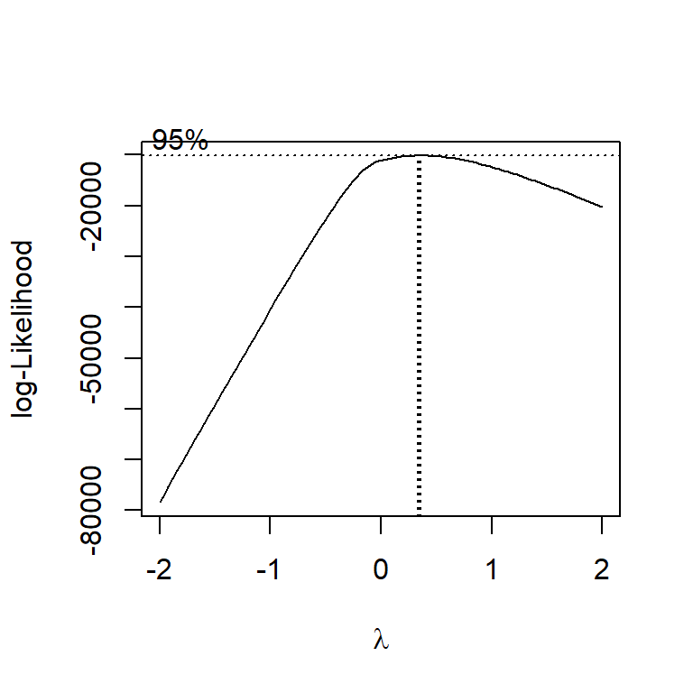

```r
best.lambda = bc$x[which.max(bc$y)]

#Use the lambda found from boxcox method and do model diagnostics
fit_revenue_add_lambda = lm(revenue^best.lambda  ~ budget + popularity + vote_count + release_month + first_genre,data = tmdb_movies_train)

results_add_lambda = get_model_results(fit_revenue_add_lambda)
revenue_mod_results_discard = rbind(revenue_mod_results_discard,
                          (tibble_row(model_name = "Best Lambda Additive",
                                      model = results_add_lambda$model,
                                      model_rse = results_add_lambda$model_rse,
                                      adj_r2 = results_add_lambda$adj_r2,
                                      model_test_rmse = results_add_lambda$model_test_rmse,
                                      num_params = results_add_lambda$num_params,
                                      sw_value = results_add_lambda$sw_value,
                                      sw_decision = results_add_lambda$sw_decision,
                                      bp_value = results_add_lambda$bp_value,
                                      bp_decision = results_add_lambda$bp_decision

                                      )))
```

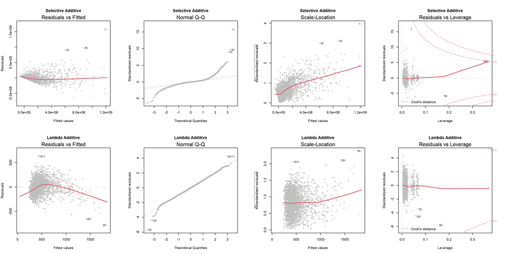

```r
par(mar = c(5, 4, 5, 4), mfrow = c(2, 4))
plot(fit_revenue_add_sel,
    col = "grey",
    pch = 20,
    lwd = 2,
    main = "Selective Additive")

plot(fit_revenue_add_lambda,
    col = "grey",
    pch = 20,
    lwd = 2,
    main = "Lambda Additive")
```

The QQ plot looks better after box cox transformation, but the normal vs residual plot indicated presence of non linearity.

## Interaction Model

We rescan the scatter plots between the chosen predictors to add interaction and higher order terms to the additive model. We add a new column that contains the value of $revenue ^ \lambda$ to evaluate the relationships against our higher order response variable.

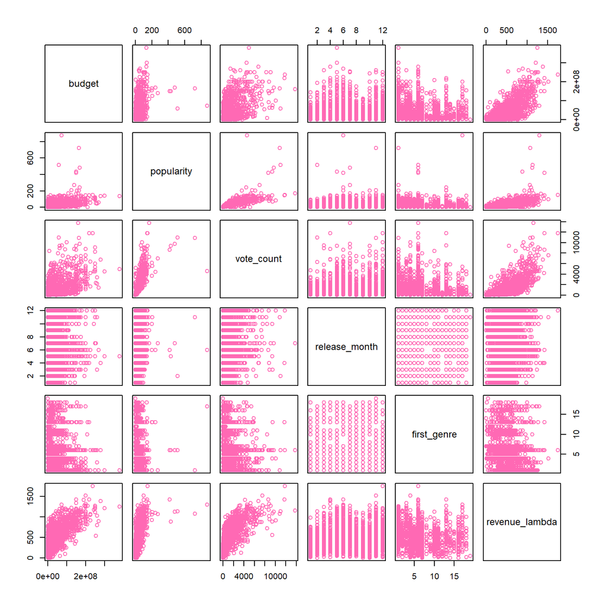

```r
# Check for polynomial and interaction relationships with powered revenue
retain_col = c("budget", "popularity", "vote_count", "release_month", "first_genre")
tmdb_temp = tmdb_movies_train[retain_col]
tmdb_temp$revenue_lambda = tmdb_movies_train$revenue ^ best.lambda

pairs(tmdb_temp, col = cbPalette[3])
```

Polynomial and interaction terms are added based on visual inspection of the pairs plot and we obtain the results for this interactive polynomial model. A stepwise backward search is once again performed, with AIC as the criterion. We then obtain the performance results for the best model.

```r
#Add polynomial and interaction terms, based on visual inspection of pairs plot

fit_revenue_int_sel = lm(revenue^best.lambda  ~ budget + popularity + sqrt(vote_count) + release_month + first_genre +  budget*vote_count*release_month + I(budget^2) + I(popularity^2) +  I(popularity^3) + I(vote_count^2),data = tmdb_movies_train)

results_int_sel = get_model_results(fit_revenue_int_sel, lambda = best.lambda)
```

```
## Model: revenue^best.lambda ~ budget + popularity + sqrt(vote_count) + release_month + first_genre + budget * vote_count * release_month + I(budget^2) + I(popularity^2) + I(popularity^3) + I(vote_count^2) lambda: 0.3434
```

```r
revenue_mod_results = rbind(revenue_mod_results,
                          (tibble_row(model_name = "Interactive/Polynomial",
                                      model = results_int_sel$model,
                                      model_rse = results_int_sel$model_rse,
                                   model_test_rmse = results_int_sel$model_test_rmse,
                                   num_params = results_int_sel$num_param,
                                      adj_r2 = results_int_sel$adj_r2,
                                      sw_value = results_int_sel$sw_value,
                                      sw_decision = results_int_sel$sw_decision,
                                      bp_value = results_int_sel$bp_value,
                                      bp_decision = results_int_sel$bp_decision

                                      )))
```

```r
# Backward search using AIC criterion
fit_revenue_int_best = step(fit_revenue_int_sel, trace =FALSE)

results_int_best = get_model_results(fit_revenue_int_best, lambda = best.lambda)
```

```
## Model: revenue^best.lambda ~ budget + sqrt(vote_count) + release_month + first_genre + vote_count + I(budget^2) + I(vote_count^2) + budget:vote_count + budget:release_month + release_month:vote_count + budget:release_month:vote_count lambda: 0.3434
```

```r
revenue_mod_results = rbind(revenue_mod_results,
                          (tibble_row(model_name = "Interactive/Polynomial AIC",
                                      model = results_int_best$model,
                                        model_rse = results_int_best$model_rse,
                                      adj_r2 = results_int_best$adj_r2,
                                         model_test_rmse = results_int_best$model_test_rmse,
                                          num_params = results_int_best$num_params,
                                      sw_value = results_int_best$sw_value,
                                      sw_decision = results_int_best$sw_decision,
                                      bp_value = results_int_best$bp_value,
                                      bp_decision = results_int_best$bp_decision

                                      )))
```

## Other Approaches

To complete the search for a good model, other attempted approaches start with the full additive model as a baseline:

- Use log(revenue) as target variable
- Use Backward search with BIC as the criterion to see if a smaller additive model will give desired performance

```r
fit_log_revenue_add = lm(log(revenue) ~ .,
                     data = tmdb_movies_train)

results_log_add = get_model_results(fit_log_revenue_add)
revenue_mod_results_discard = rbind(revenue_mod_results_discard,
                          (tibble_row(model_name = "full log additive",
                                      model = results_log_add$model,
                                      model_rse = results_log_add$model_rse,
                                      adj_r2 = results_log_add$adj_r2,
                                      model_test_rmse = results_log_add$model_test_rmse,
                                      num_params = results_log_add$num_params,
                                      sw_value = results_log_add$sw_value,
                                      sw_decision = results_log_add$sw_decision,
                                      bp_value = results_log_add$bp_value,
                                      bp_decision = results_log_add$bp_decision
                                      )))
```

```r
n = nrow(tmdb_movies_train)
fit_revenue_both_bic = step(lm(revenue ~ 1, data = tmdb_movies_train),
                             scope = revenue ~ budget + popularity + vote_average +
                              vote_count + runtime + release_month + first_genre + is_big_banner,
                             direction = "both",
                             k = log(n),
                             trace = 0)

results_both_bic = get_model_results(fit_revenue_both_bic)
revenue_mod_results_discard = rbind(revenue_mod_results_discard,
                          (tibble_row(model_name = "Bidirectional BIC",
                                      model = results_both_bic$model,
                                      model_rse = results_both_bic$model_rse,
                                      adj_r2 = results_both_bic$adj_r2,
                                      model_test_rmse = results_both_bic$model_test_rmse,
                                      num_params = results_both_bic$num_params,
                                      sw_value = results_both_bic$sw_value,
                                      sw_decision = results_both_bic$sw_decision,
                                      bp_value = results_both_bic$bp_value,
                                      bp_decision = results_both_bic$bp_decision
                                      )))
```

# Results

Our model search process covers a total of eight different models. For each model under consideration, we obtain the performance metrics, which is used to decide on the final model(s) of choice. A basic requirement is that the model has to perform better than our baseline. Since prediction is our goal, Test RMSE is an important decision factor.

## Best Model Shortlist

Narrowing the models down to a shortlist is the first step and we use both visual charts and performance metrics to select the best model(s). We retain the simple additive model as the baseline in the shortlist.

```r
knitr::kable(revenue_mod_results[,1:6],
              caption = "<center><strong>Revenue Model Selection</strong></center>") %>%
          kable_styling(bootstrap_options = c("striped", "hover", "condensed", "responsive"))
```

**Revenue Model Selection**

| model_name | model | model_rse | adj_r2 | model_test_rmse | num_params |
| --- | --- | --- | --- | --- | --- |
| Baseline | budget + popularity | 1.169e+08 | 0.6061 | 105.46 | 3 |
| Interactive/Polynomial | budget + popularity + sqrt(vote_count) + release_month + first_genre + budget * vote_count * release_month + I(budget^2) + I(popularity^2) + I(popularity^3) + I(vote_count^2) | 1.263e+02 | 0.7501 | 96.99 | 72 |
| Interactive/Polynomial AIC | budget + sqrt(vote_count) + release_month + first_genre + vote_count + I(budget^2) + I(vote_count^2) + budget:vote_count + budget:release_month + release_month:vote_count + budget:release_month:vote_c… | 1.262e+02 | 0.7501 | 96.72 | 69 |

As the numbers demonstrate, the models in this shortlist are better on all fronts when compared with the Baseline model:

- Lower Residual Standard Error than the Baseline model
- Higher Adjusted $R^2$ than the Baseline model
- Lower Test RMSE than the Baseline model

A plot of the charts for the two models in the shortlist also demonstrates that the two models improve the normality and constant variance assumptions as compared to the Baseline model.

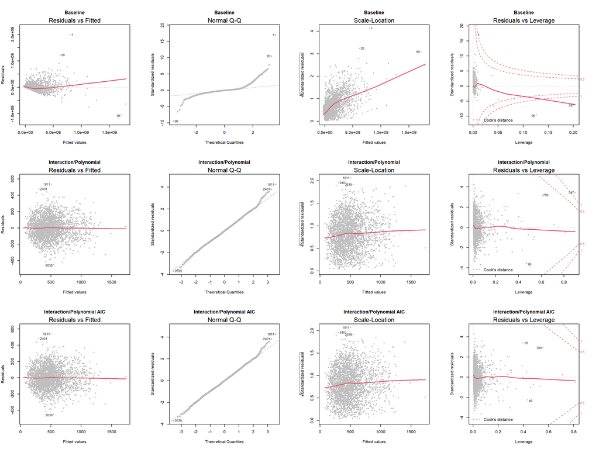

```r
par(mar = c(5, 4, 5, 4), mfrow = c(3, 4))

plot(boxoffice_model_1,
     col = "grey",
     pch = 20,
     lwd = 2,
     main = "Baseline")

plot(fit_revenue_int_sel,
     col = "grey",
     pch = 20,
     lwd = 2,
     main = "Interaction/Polynomial")

plot(fit_revenue_int_best,
     col = "grey",
     pch = 20,
     lwd = 2,
     main = "Interaction/Polynomial AIC")
```

## Discarded Models

In addition to the shortlist, we also create a table of the performance metrics of the discarded models. Apart from interesting insights about the inferior performance of the individual models, the models collectively strengthen the decision about the best model.

```r
knitr::kable(revenue_mod_results_discard[,1:6],
              caption = "<center><strong>Discarded Models </strong></center>") %>%
          kable_styling(bootstrap_options = c("striped", "hover", "condensed", "responsive"))
```

**Discarded Models**

| model_name | model | model_rse | adj_r2 | model_test_rmse | num_params |
| --- | --- | --- | --- | --- | --- |
| Full Additive | budget + popularity + vote_average + vote_count + runtime + release_month + release_year + first_genre + is_big_banner | 1.018e+08 | 0.7194 | 94.06 | 37 |
| AIC Selective Additive | budget + popularity + vote_count + release_month + release_year + first_genre | 1.018e+08 | 0.7194 | 94.24 | 34 |
| Best Lambda Additive | budget + popularity + vote_count + release_month + first_genre | 1.483e+02 | 0.6553 | 200.37 | 33 |
| full log additive | budget + popularity + vote_average + vote_count + runtime + release_month + release_year + first_genre + is_big_banner | 1.459e+00 | 0.4166 | 200.37 | 37 |
| Bidirectional BIC | vote_count + budget + popularity | 1.043e+08 | 0.7054 | 97.14 | 4 |

## Best Model Callout

This model has a the highest model complexity of all the models we considered, but we still select it because our goal is prediction of revenue and not explanation of the data.

```r
fit_revenue_best = fit_revenue_int_sel
fit_revenue_best_mse = results_int_sel$model_mse
fit_revenue_best_adj_r2_b = results_int_sel$adj_r2
fit_revenue_best_rmse = results_int_sel$model_test_rmse
fit_revenue_best_sw_decision = results_int_sel$sw_decision
fit_revenue_best_num_params = results_int_sel$num_params
fit_revenue_best_preds = as.character(as.formula(fit_revenue_int_sel))[3]
```

# Discussion

We do further analysis of the best model’s parameters, assumption compliance and predictions using the test dataset, tmdb_movies_test.

## Model Assumptions

The chosen model rejects the constant variance (BP) and normality (Shapiro) tests (with $\alpha$ = 0.01) although the Q-Q plot and residual vs fitted values looks reasonable as seen below.The fat tails in Q-Q plot is not concerning given that they only represent <5% of the data.

Moreover the model is primarily being used for prediction not inference hence overall we are not overly concerned about the BP and Shapiro test rejections.

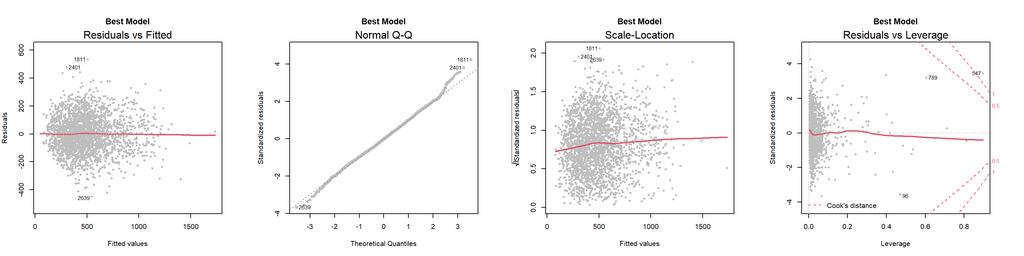

```r
par(mar = c(5, 4, 5, 4), mfrow = c(1, 4))

plot(fit_revenue_best,
     col = "grey",
     pch = 20,
     lwd = 2,
     main = "Best Model")
```

## Prediction Quality

```r
par(mar = c(5, 4, 5, 4), mfrow = c(1, 2))
predicted_revenue = get_predicted(fit_revenue_best, lambda = best.lambda) / 10 ^ 6
```

```
## Model: revenue^best.lambda ~ budget + popularity + sqrt(vote_count) + release_month + first_genre + budget * vote_count * release_month + I(budget^2) + I(popularity^2) + I(popularity^3) + I(vote_count^2) lambda: 0.3434
```

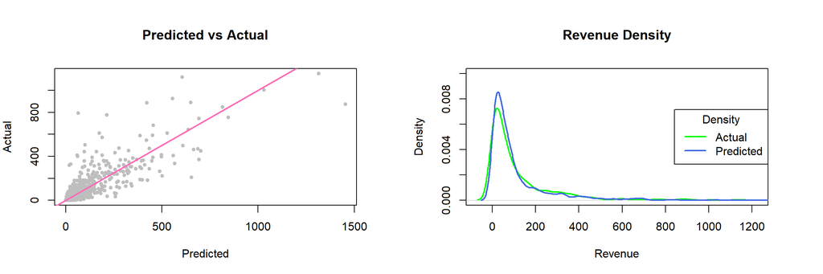

```r
actual_revenue = tmdb_movies_test$revenue / 10 ^ 6
average_percent_error = mean(abs(predicted_revenue - actual_revenue) /
                              predicted_revenue) * 100

revenue_cutoff = 300
le_cutoff_ind = actual_revenue <= revenue_cutoff
gt_cutoff_ind = actual_revenue > revenue_cutoff
average_percent_error_le_cutoff = mean(abs(predicted_revenue[le_cutoff_ind] - actual_revenue[le_cutoff_ind]) /
                              predicted_revenue[le_cutoff_ind]) * 100

average_percent_error_gt_cutoff = mean(abs(predicted_revenue[gt_cutoff_ind] - actual_revenue[gt_cutoff_ind]) /
                              predicted_revenue[gt_cutoff_ind]) * 100

#plot 1
plot(predicted_revenue, actual_revenue, col = "grey", pch = 20,
xlab = "Predicted", ylab = "Actual",
main = "Predicted vs Actual")

abline(0, 1, col = cbPalette[3], lwd = 2)

#plot 2
plot(density(actual_revenue), col = cbPalette[4], lwd = 2,
xlab = "Revenue", ylab = "Density",
ylim = c(0, 0.01),
main = "Revenue Density")
lines(density(predicted_revenue), col = cbPalette[5], lwd = 2)

legend("right",
       title = "Density",
       legend = c("Actual", "Predicted"),
       lwd = 2,
       col = c(cbPalette[4], cbPalette[5]))
```

The average percent error when we use our best model to predict the values for our test dataset is 76.8717%. This means we are not able to predict accurately three out of four times. This is a high rate of error for a ‘good’ model.

The tmdb_movies_test set has revenue values in the range (12, 1153304495) and the median revenue is 55946785. Our test RMSE amounts to 173.3526% of the median revenue which is too high relative to the revenue.

We explore further if the model error rate is different for smaller versus larger revenue movies in the test dataset. We set a revenue cutoff of 300 to test this:

- 69.8888 is the average percent error for movies whose actual revenue is less than the cutoff.
- 132.1532 is the average percent error for movies whose actual revenue is greater than the cutoff.

## Next Steps

Our overall conclusion is that the model we have come up with is not sufficient to predict revenue accurately. We will need to change our criteria and reiterate the process of model selection. We outline a few next steps below:

- As seen from the revenue density distributions, revenue is heavily skewed to the right in our dataset. Currently we have split the tmdb_movies dataset into train and test dataset using random selection. A future step could be tp ensure if our train and test datasets mirror this revenue distribution.
- As observed from the results, the best model performs better for low budget movies then the high budget ones. In our future work, we need to explore having seprate models for low versus high budget movies as the predictors for the two groups might be different.
- Other potential next steps include discovering other predictors which can help us create a model with better performance metrics (which was considered above). One possibility is to expand the input dataset to include actor details with their previous hits/revenue etc which can help us predict better. This can help us create a better model with historical information for an actor.
- Currently our model selection process uses backward and bidirectional searches with a preliminary starting model that includes predictors based on visual analysis of correlations. With sufficient compute resources, a next step would be to use exhaustive model search using *regsubsets* to yield a better model.

# Appendix

## Model Building: Support Methods

To create a structured approach to the model building process, we implemented a number of support methods:

```r
library(lmtest)

get_bp_decision = function(model, alpha) {
  decide = unname(bptest(model)$p.value < alpha)
  ifelse(decide, "Reject", "Fail to Reject")
}

get_sw_decision = function(model, alpha) {
  decide = unname(shapiro.test(resid(model))$p.value < alpha)
  ifelse(decide, "Reject", "Fail to Reject")
}

get_num_params = function(model) {
  length(coef(model))
}

get_loocv_rmse = function(model) {
  sqrt(mean((resid(model) / (1 - hatvalues(model))) ^ 2))
}

get_adj_r2 = function(model) {
  summary(model)$adj.r.squared
}

get_rse = function(model) {
  summary(model)$sigma
}

get_predicted = function(model, lambda = NA) {
  predicted = predict( model, newdata = tmdb_movies_test )

  # Response is units of ^lambda convert back to linear units before calculating RMSE
  if(!is.na(lambda))
  {
    cat("Model:", deparse1(model$call$formula), "lambda:", lambda)
    # Response is in log scale
    if( lambda ==0)
    {
      predicted = exp(predicted)
    }
    else if (!is.na(lambda))
    {
      predicted =  predicted^(1/lambda)
    }
  }

  return(predicted)
}

get_rmse = function(model, lambda = NA) {
  mse=anova(model)['Residuals', 'Mean Sq']

  predicted = get_predicted( model, lambda)
  actual_revenue = tmdb_movies_test$revenue

  rmse(actual_revenue, predicted)/10^6
}


get_model_results = function(model, alpha = 0.01, lambda = NA) {
  model_str = as.character(as.formula(model))[3]
  loocv_rmse = get_loocv_rmse(model)
  adj_r2 = get_adj_r2(model)
  bp_decision = get_bp_decision(model, alpha)
  bp_value = bptest(model)$p.value
  sw_decision = get_sw_decision(model, alpha)
  sw_value = shapiro.test(resid(model))$p.value
  num_params = get_num_params(model)
  model_rse =  get_rse(model)
  model_test_rmse = get_rmse(model, lambda)

  list(
       model = model_str,
       loocv_rmse = loocv_rmse,
       adj_r2 = adj_r2,
       bp_decision = bp_decision,
       bp_value = bp_value,
       sw_decision = sw_decision,
       sw_value = sw_value,
       num_params = num_params,
       model_rse = model_rse,
       model_test_rmse=model_test_rmse)
}

pasteFormula = function(outcome, variables) {
  pastef = ""
  if (!is.null(outcome)) {
    pastef = paste(outcome, paste(variables, collapse = " + "), sep = " ~ ")
  } else {
    pastef = paste(" ~ ", paste(variables, collapse = " + "))
  }
  return (pastef)
}

removeInfluencers = function(data) {
  model = lm(revenue ~ ., data=data)
  cd_mod_a = cooks.distance(model)
  influential_ind = cd_mod_a > 4 / length(cd_mod_a)
  data_modified = data[influential_ind == FALSE, ]
  return (data_modified)
}
```

## Team

The names of the students who contributed to this group project:

- **amana4** (Aman Arora)
- **dani4** (Savvy Dani)
- **gaurav4** (Gaurav Shrivastava)